# Stat 101C Final Project

Mizuki Kio

May 24, 2017

My attempt here is to develop the following prediction algorithm:

1. For a given observation, search for other observations that have the same incident ID
2. Find the maximum dispatch sequence in that incident and classify the incident into one of the 3 severity levels (like “small”, “middle”, or “big”)
3. Predit response using a linear model that is fit to a specific indicident level

```r
#load library
library(dplyr)
```

```r
library(ggplot2)
```

# First Step: load data, take a sample of the incidents

To save computational power, we will train the model only on a sample of incidents.

```r
setwd("D:/UCLA Document/2016-2017/Spring 2017/Stats 101C/Final Project")

#load data
library(readr)
lafd <- read_csv("D:/UCLA Document/2016-2017/Spring 2017/Stats 101C/Final Project/lafdtraining.csv")
testing <- read_csv("D:/UCLA Document/2016-2017/Spring 2017/Stats 101C/Final Project/testing.without.response.csv")
#remove NA
lafd = na.omit(lafd)

#Randomly select 1000 incidents
incidents_full = unique(lafd$incident.ID) #create a list of all unique incident IDs
set.seed(123)
incidents_sample = incidents_full[sample(1:length(incidents_full), size = 1000)] #randomly select 1000 of them

lafd_sample = lafd[0,]

#extract and store rows in original full data with Incident IDs that match our 1000 sample IDs
for(i in 1:length(incidents_sample)){
  lafd_sample = rbind(lafd_sample, filter(lafd, incident.ID == incidents_sample[i]) )
}

head(lafd_sample) #now we have a data frame with 1000 randomly-selected incidents only
```

```
## # A tibble: 6 × 11
##    row.id        incident.ID  year `First in District`
##     <int>              <chr> <int>               <int>
## 1 3110092 FD26028.5693889029  2014                  27
## 2 1401498 FD26029.5610277944  2016                  67
## 3 3232024 FD26028.5795465493  2014                  46
## 4 1278002 FD26029.5678971589  2016                  46
## 5  470476 FD26029.5719638543  2016                  61
## 6 2309968 FD26029.5719638543  2016                  61
## # ... with 7 more variables: `Emergency Dispatch Code` <chr>, `Dispatch
## #   Sequence` <int>, `Dispatch Status` <chr>, `Unit Type` <chr>, `PPE
## #   Level` <chr>, `Incident Creation Time (GMT)` <time>,
## #   elapsed_time <int>
```

# Analyze the incidents, look for patterns that we can use to classify incidents into a small number of categories

Goal: Find a criteria that we can use to classify incidents into several categories (like 3~5) where incidents in each group are “similar” to each other.

Let’s try Max Dispatch Sequence first…

```r
incidents_sample_df = data.frame(incident.ID = incidents_sample)
incidents_sample_df$maxDispatch = c()

#Find the maximum dispatch sequence for each incident
for(i in 1:nrow(incidents_sample_df)){
  incidents_sample_df$maxDispatch[i] = lafd_sample[lafd_sample$incident.ID == incidents_sample[i], "Dispatch Sequence"] %>% max()
}

table(incidents_sample_df$maxDispatch)
```

```
##
##   1   2   3   4   5   6   8   9  10  11  13  15  16  58
## 354 437 150  35   7   7   1   1   1   1   2   2   1   1
```

```r
#based on the table, we decide to classify incidents into 3 severity levels as follows:

incidents_sample_df$severity = rep(NA,nrow(incidents_sample_df))

incidents_sample_df[incidents_sample_df$maxDispatch %in% c(1,2), "severity"] = 1
incidents_sample_df[incidents_sample_df$maxDispatch %in% c(3,4), "severity"] = 2
incidents_sample_df[incidents_sample_df$maxDispatch >= 5, "severity"] = 3

table(incidents_sample_df$severity)
```

```
##
##   1   2   3
## 791 185  24
```

Now we incorporate our classification into the sample data frame.

```r
lafd_sample$severity = c()
#extract rows in sample data with Incident IDs that match our 1000 sample IDs
#assign to severity column values extracted from incidents_sample_df
for(i in 1:length(incidents_sample)){
  lafd_sample[lafd_sample$incident.ID == incidents_sample[i], "severity"] = incidents_sample_df[i, "severity"]
}
```

# Analyze response variable, elapsed_time

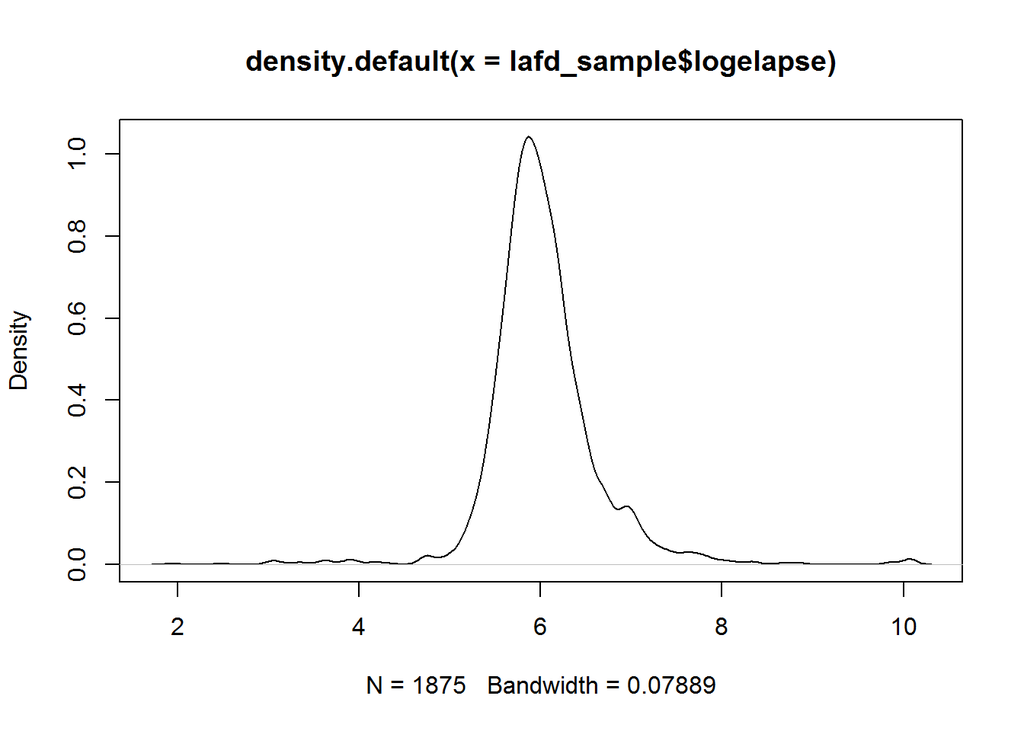

```r
#Since the distribution of elapsed_time is heavily skewed, we take a log to make it normal
lafd_sample$logelapse = log(lafd_sample$elapsed_time)
plot(density(lafd_sample$logelapse)) #it's still far from normal but it's a lot better
```

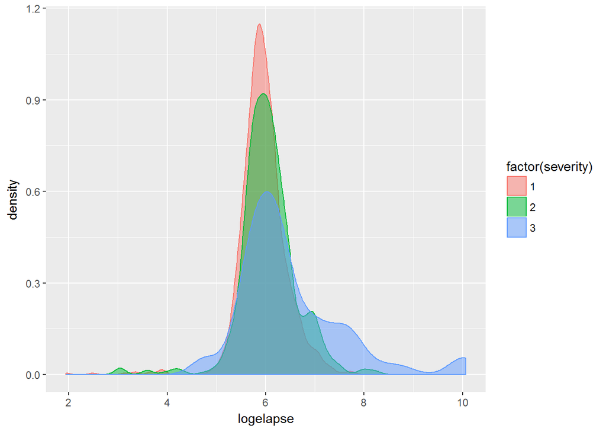

```r
#Density of log_elapse by different severity levels:
ggplot(data = lafd_sample, aes(x = logelapse, color = factor(severity), fill = factor(severity))) + geom_density(alpha=.5)
```

It seems that there is not much difference in the distribution of log_elapsed_time among incidents of different severity levels. Thus it may not be a good idea to fit seperate models to different severity models.

We terminate this attempt as we did not find any meaningful difference in the distribution of response variable with respect to severity levels determined by the maxmimum dispatch sequence.